# Caturan Project 2C

Scientific question: How does an active cycle of breathing techniques and aerobic exercise training affect the physical fitness, as measured by muscle endurance and speed, of young children between the ages of 5-13 with cystic fibrosis?

Scientific background: Cystic fibrosis is a multisystem disease that primarily affects the respiratory system. CF occurs due to a mutation that makes the cystic fibrosis transmembrane regulator (CTFR) nonfunctional. The CTFR is responsible for secreting saline into the airway epithelium, making it possible for mucus to be expelled normally; for instance, mucus is typically moved by cilia up the airways, which causes you to cough it out or travel down into your stomach. With a mutated CTFR, no saline is added to the mucus of the airway, making the mucus thick and viscous. As a result, the cilia of the mucociliary escalator is unable to move mucus out of the airway. As a result, the thick mucus ends up becoming a breeding ground for germs and pathogens, which makes CF patients more prone to respiratory infection. While this disorder has no cure, a variety of treatments have been proven to help alleviate the symptoms of patients who suffer with CF. For instance, exercise has been proven to increase forced expiration and mucus clearance, decrease the feeling of shortness of breath, and support a feeling of wellness (Bulent). Although, a common obstacle faced by patients suffering from CF is that because of their illness, they have little to no exercise tolerance and an overall feeling of breathlessness, so it is difficult to get CF patients into a regular exercise routine without addressing the pulmonary symptoms they are faced with. In order to address those symptoms, it must be taken into consideration whether it would be beneficial to provide CF patients with some kind of pulmonary rehabilitation alongside their medical treatments, and whether breathing techniques will allow these patients to exercise comfortably and therefore improve their overall quality of life. Ultimately, what will be investigated here are the effects of aerobic exercise training in combination with an active cycle of breathing techniques, and whether the combination of these two techniques will improve the muscle endurance and strength of cystic fibrosis patients ranging from ages 5 to 13 years old.

Scientific hypothesis: If clinically stable pediatric cystic fibrosis patients undergo an active cycle of breathing techniques in addition to aerobic exercise training, then their thoracic mobility and physical fitness parameters such as muscle endurance and speed will increase.

In order to address the above scientific hypothesis, we will use the paired sample t-test to determine whether the relationship between an active cycle of breathing techniques/aerobic exercise training, muscle endurance, and speed are statistically significant. In order to evaluate for muscle endurance, the sit-ups test data will be used, and to assess for speed, the shuttle run data will be used. Histograms will be used to visualize any trends between the program and each physical fitness test. Finally, a Deep Neural Network will be used to determine whether vital capacity (VC) and FEV1 are able to be used to predict shuttle run times in pediatric cystic fibrosis patients.

The paired sample t-test has been chosen to generate p-values of this study because we are interested in comparing the differences between the same two variables for the same group of subjects. More specifically, all 20 patients were instructed to perform the sit-up and shuttle run tests before and after their breathing and aerobic exercise training programs.

The following packages will need to be installed and loaded for this data analysis:

```r
library(neuralnet)
```

Bulent’s article provided data for before/after training sit-up test results, before/after training shuttle run results, ages, weights, heights, vital capacities, and forced expiratory volumes. Although, the article only provided means and standard deviations. So, in order to proceed with this data analysis, 20 data points for each of the mentioned characteristics were randomly generated in R. An example of the code used to randomly generate the data is included below. The exact same code was done for each of the sit-up/shuttle run tests, as well as the general characteristics of the patients.

```r
#Generating a vector of 20 data points given the mean and standard deviation of 'before training' sit-up test
situps_beforetraining <- rnorm(20, mean = 25.87, sd = 7.5)
situps_beforetraining
```

```
 [1] 26.588583 21.084335 33.733130 24.591868 31.315322 34.627125 13.240684 16.911064 34.669126 26.425889
[11]  9.976013 15.966732 26.726847 22.175833 39.255818 18.147171 31.873017 16.898870 31.099548 22.972089
```

At this point, data points have been collected based on the means and standard deviations from the Bulent article. An Excel sheet has been formulated using these data points, and this excel sheet will be read into this Notebook to be used in the visualizing of both the sit-up test (measuring muscle endurance) and the shuttle run test (measuring speed).

```r
#Reading in the my_data excel sheet
my_data <- read.csv("BIMM 143 Project 2.csv")
my_data
```

| Patient | situps_beforetraining | situps_aftertraining | shuttlerun_beforetraining | shuttlerun_aftertraining | age_years | length_cm | weight_kg | vital_capacity | forced_expiratory_volume | SR_time |
| --- | --- | --- | --- | --- | --- | --- | --- | --- | --- | --- |
| 1 | 20.77816 | 18.08582 | 6.755809 | 6.972755 | 10.899223 | 116.2547 | 16.09688 | 89.93168 | 95.03569 | 6 to 7 |
| 2 | 14.02518 | 27.85309 | 5.490255 | 4.330885 | 9.905910 | 110.1017 | 12.75437 | 106.09243 | 69.53492 | 4 to 5 |
| 3 | 27.39264 | 15.06907 | 4.902491 | 2.846742 | 7.913737 | 109.1595 | 10.88082 | 88.97145 | 88.67809 | 2 to 3 |
| 4 | 22.19942 | 26.59309 | 4.898579 | 4.882872 | 8.480205 | 109.6496 | 23.63398 | 106.10499 | 81.36865 | 4 to 5 |
| 5 | 34.65923 | 36.02964 | 5.283449 | 5.616911 | 7.973454 | 122.8385 | 30.22627 | 87.68594 | 86.80394 | 5 to 6 |
| 6 | 27.39736 | 39.09803 | 6.715998 | 5.362695 | 10.071491 | 110.5876 | 20.53849 | 83.95847 | 96.91270 | 5 to 6 |
| 7 | 28.91201 | 34.69716 | 6.505560 | 5.028537 | 13.620429 | 114.9551 | 37.77182 | 81.19468 | 98.88511 | 5 to 6 |
| 8 | 27.01878 | 25.81127 | 6.129403 | 4.431714 | 9.907081 | 133.3406 | 32.95096 | 85.01707 | 104.65674 | 4 to 5 |
| 9 | 11.68027 | 31.55643 | 5.365615 | 6.213095 | 12.027253 | 123.3516 | 38.38492 | 82.81337 | 78.25159 | 6 to 7 |
| 10 | 25.84233 | 36.50032 | 4.811191 | 5.435373 | 8.251536 | 120.6700 | 27.41402 | 91.72499 | 77.78847 | 5 to 6 |

[output cut: 10 more lines]

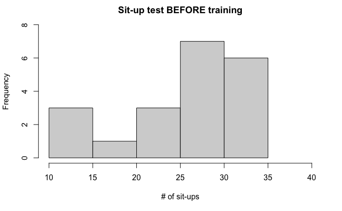

```r
#Comparing the histograms of before and after training for sit-up test
hist(my_data$situps_beforetraining, xlim = c(10, 40), ylim = c(0,8), main = "Sit-up test BEFORE training", xlab = "# of sit-ups")
```

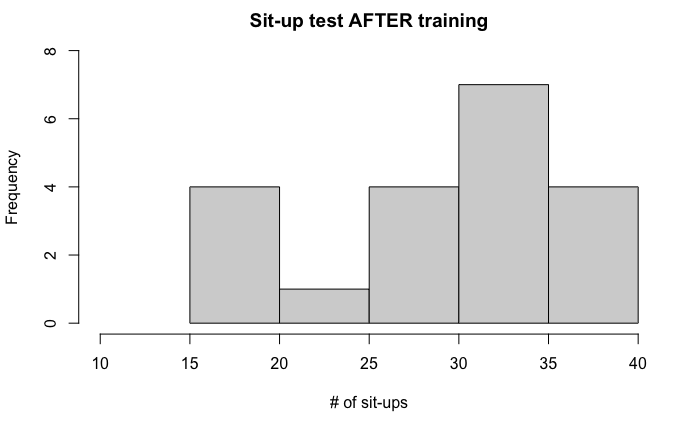

```r
hist(my_data$situps_aftertraining, xlim = c(10, 40), ylim = c(0,8), main = "Sit-up test AFTER training", xlab = "# of sit-ups")
```

Based on the histograms made for the sit-up tests before and after training, it is evident that the number of sit-ups increased after the training program. This will be further investigated using a paired sample t-test below.

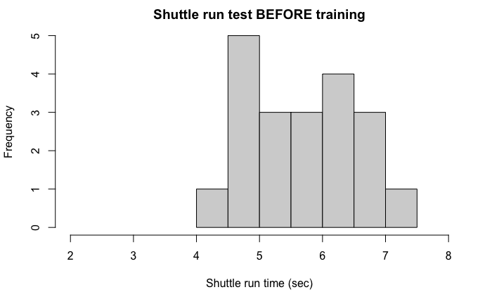

```r
#Comparing the histograms of before and after training for shuttle run test
hist(my_data$shuttlerun_beforetraining, xlim = c(2, 8), ylim = c(0,5), main = "Shuttle run test BEFORE training", xlab = "Shuttle run time (sec)")
```

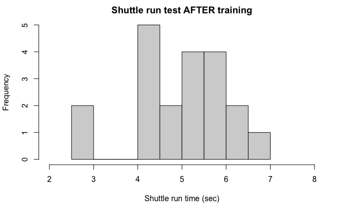

```r
hist(my_data$shuttlerun_aftertraining, xlim = c(2, 8), ylim = c(0,5), main = "Shuttle run test AFTER training", xlab = "Shuttle run time (sec)")
```

Based on the histograms made for the shuttle run tests before and after training, it is evident that the shuttle run times decreased after the training program. This will be further investigated using a paired sample t-test below.

Prior to performing a paired sample t-test, the before and after training data for the sit-up tests must be tested for normality. This is done in the following chunk.

```r
#Testing the normality of sit-up test using the Shapiro-Wilk normality test
d_situps <- my_data$situps_beforetraining - my_data$situps_aftertraining
d_situps
```

```
 [1]   2.69234 -13.82791  12.32357  -4.39367  -1.37041 -11.70067  -5.78515   1.20751 -19.87616 -10.65799
[11]   0.04317   8.70734   4.01662  -1.96325  -5.29677 -20.80222  -1.47234   2.48192   1.76333   0.50111
```

```r
shapiro.test(d_situps)
```

```
    Shapiro-Wilk normality test

data:  d_situps
W = 0.95197, p-value = 0.398
```

From the above output, the p-value is greater than the significance level 0.05 implying that the distribution of the differences (d) are not significantly different from normal distribution. In other words, we can assume the normality. Therefore, we may proceed with a paired sample t-test.

```r
#Calculating the p-value of sit-up test using a paired sample t-test
situps_result <- t.test(my_data$situps_beforetraining, my_data$situps_aftertraining, paired = TRUE)

situps_result
```

```
    Paired t-test

data:  my_data$situps_beforetraining and my_data$situps_aftertraining
t = -1.6405, df = 19, p-value = 0.1173
alternative hypothesis: true difference in means is not equal to 0
95 percent confidence interval:
 -7.2154098  0.8744468
sample estimates:
mean of the differences
              -3.170481
```

From the above output, we can see that the p-value is 0.1173, and since this p-value is not less than 0.05, we can not conclude that these results are statistically significant. More specifically, an active cycle of breathing in combination with aerobic exercise does not lead to an improvement of muscle endurance in pediatric patients with cystic fibrosis. Now the paired sample t-test will be done for the shuttle run data points.

```r
#Testing the normality of shuttle run test using the Shapiro-Wilk normality test
d_shuttle <- my_data$situps_beforetraining - my_data$situps_aftertraining
d_shuttle
```

```
 [1]   2.69234 -13.82791  12.32357  -4.39367  -1.37041 -11.70067  -5.78515   1.20751 -19.87616 -10.65799
[11]   0.04317   8.70734   4.01662  -1.96325  -5.29677 -20.80222  -1.47234   2.48192   1.76333   0.50111
```

```r
shapiro.test(d_shuttle)
```

```
    Shapiro-Wilk normality test

data:  d_shuttle
W = 0.95197, p-value = 0.398
```

```r
#Calculating the p-value of shuttle run test using a paired sample t-test
shuttle_result <- t.test(my_data$shuttlerun_beforetraining, my_data$shuttlerun_aftertraining, paired = TRUE)

shuttle_result
```

```
    Paired t-test

data:  my_data$shuttlerun_beforetraining and my_data$shuttlerun_aftertraining
t = 2.647, df = 19, p-value = 0.0159
alternative hypothesis: true difference in means is not equal to 0
95 percent confidence interval:
 0.1407966 1.2047267
sample estimates:
mean of the differences
              0.6727617
```

From the above output, we can see that the p-value is 0.0159, and since this p-value is less than 0.05, we can conclude that these results are statistically significant. More specifically, an active cycle of breathing in combination with aerobic exercise does lead to an improvement of speed in pediatric patients with cystic fibrosis.

The two following chunks will now formulate a Deep Neural Network in order to determine any possible patterns between the ages, heights, weights, vital capacities, FEV1s, and post-training shuttle run times in pediatric patients with cystic fibrosis.

```r
#A DNN will be utilized to identify any patterns between the characteristics of the 20 CF patients and their shuttle run times

#Check the structure of data to ensure it is compiled as a data frame
str(my_data)
```

```
'data.frame':   20 obs. of  11 variables:
 $ Patient                  : int  1 2 3 4 5 6 7 8 9 10 ...
 $ situps_beforetraining    : num  20.8 14 27.4 22.2 34.7 ...
 $ situps_aftertraining     : num  18.1 27.9 15.1 26.6 36 ...
 $ shuttlerun_beforetraining: num  6.76 5.49 4.9 4.9 5.28 ...
 $ shuttlerun_aftertraining : num  6.97 4.33 2.85 4.88 5.62 ...
 $ age_years                : num  10.9 9.91 7.91 8.48 7.97 ...
 $ length_cm                : num  116 110 109 110 123 ...
 $ weight_kg                : num  16.1 12.8 10.9 23.6 30.2 ...
 $ vital_capacity           : num  89.9 106.1 89 106.1 87.7 ...
 $ forced_expiratory_volume : num  95 69.5 88.7 81.4 86.8 ...
 $ SR_time                  : chr  "6 to 7" "4 to 5" "2 to 3" "4 to 5" ...
```

```r
#Load neuralnet package
library(neuralnet)

#Create DNN using age, height, weight, vital capacity, and forced expiratory volume
nn <- neuralnet(SR_time ~ age_years + length_cm + weight_kg + vital_capacity + forced_expiratory_volume, my_data, linear.output = FALSE)
nn
```

```
$call
neuralnet(formula = SR_time ~ age_years + length_cm + weight_kg +
    vital_capacity + forced_expiratory_volume, data = my_data,
    linear.output = FALSE)

$response
   6 to 7 4 to 5 2 to 3 5 to 6
1   FALSE  FALSE  FALSE   TRUE
2   FALSE   TRUE  FALSE  FALSE
3    TRUE  FALSE  FALSE  FALSE
4   FALSE   TRUE  FALSE  FALSE
5   FALSE  FALSE   TRUE  FALSE
6   FALSE  FALSE   TRUE  FALSE
7   FALSE  FALSE   TRUE  FALSE
8   FALSE   TRUE  FALSE  FALSE
9   FALSE  FALSE  FALSE   TRUE
10  FALSE  FALSE   TRUE  FALSE
11  FALSE  FALSE  FALSE   TRUE
12  FALSE   TRUE  FALSE  FALSE
13  FALSE   TRUE  FALSE  FALSE
14  FALSE  FALSE   TRUE  FALSE
15  FALSE   TRUE  FALSE  FALSE
16  FALSE  FALSE   TRUE  FALSE
17  FALSE  FALSE   TRUE  FALSE
18  FALSE  FALSE   TRUE  FALSE
19   TRUE  FALSE  FALSE  FALSE
20  FALSE   TRUE  FALSE  FALSE

$covariate
      age_years length_cm weight_kg vital_capacity forced_expiratory_volume
 [1,] 10.899223  116.2547  16.09688       89.93168                 95.03569
 [2,]  9.905910  110.1017  12.75437      106.09243                 69.53492
 [3,]  7.913737  109.1595  10.88082       88.97145                 88.67809
 [4,]  8.480205  109.6496  23.63398      106.10499                 81.36865
 [5,]  7.973454  122.8385  30.22627       87.68594                 86.80394
 [6,] 10.071491  110.5876  20.53849       83.95847                 96.91270
 [7,] 13.620429  114.9551  37.77182       81.19468                 98.88511
 [8,]  9.907081  133.3406  32.95096       85.01707                104.65674
 [9,] 12.027253  123.3516  38.38492       82.81337                 78.25159
[10,]  8.251536  120.6700  27.41402       91.72499                 77.78847
```

[output cut: 225 more lines]

```
length_cm.to.1layhid1                -0.720169318
weight_kg.to.1layhid1                -2.614134240
vital_capacity.to.1layhid1           -0.059198049
forced_expiratory_volume.to.1layhid1  1.220924931
Intercept.to.6 to 7                  -3.367667665
1layhid1.to.6 to 7                    5.464407871
Intercept.to.4 to 5                  -0.453056331
1layhid1.to.4 to 5                   -7.724246060
Intercept.to.2 to 3                  -0.234880731
1layhid1.to.2 to 3                   -5.431570365
Intercept.to.5 to 6                  -1.773317747
1layhid1.to.5 to 6                    0.566658390

attr(,"class")
[1] "nn"
```

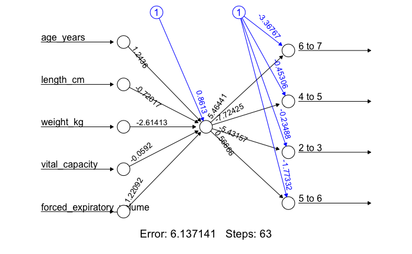

```r
#Plot variable nn
plot(nn)
```

Now that the neural network has been plotted, the data will now be trained to predict shuttle run times given the ages, heights, weights, vital capacities, and FEV1s of pediatric cystic fibrosis patients.

```r
#Using 2/3 of the collected data in my_data, train the neural network in order to predict approximate shuttle run times (SR_time)
train_idx <- sample(nrow(my_data), 2/3 * nrow(my_data))
sr_train <- my_data[train_idx, ]
sr_test <- my_data[-train_idx, ]

#Now use the trained data to predict approximate shuttle run times.
nn <- neuralnet((SR_time == "2 to 3") + (SR_time == "4 to 5") + (SR_time == "5 to 6") + (SR_time == "6 to 7")
                 ~ age_years + length_cm + weight_kg + vital_capacity + forced_expiratory_volume, sr_train, linear.output = FALSE)
pred <- predict(nn, sr_test)
pred
```

```
         [,1]      [,2]         [,3]         [,4]
1  0.08825946 0.2708601 4.983074e-01 1.992949e-01
2  0.02102179 0.9889925 2.578655e-96 1.538561e-97
3  0.06779038 0.5130805 6.905132e-19 1.317474e-19
7  0.08826184 0.2708388 4.993870e-01 1.999894e-01
10 0.08826184 0.2708388 4.993870e-01 1.999894e-01
18 0.08826184 0.2708388 4.993870e-01 1.999894e-01
20 0.02102179 0.9889926 2.578562e-96 1.538505e-97
```

```r
#Display predictions in a table
table(sr_test$SR_time, apply(pred, 1, which.max))
```

```
         2 3
  2 to 3 1 0
  4 to 5 2 0
  5 to 6 0 3
  6 to 7 0 1
```